# Ensembles

> The interests of truth require a diversity of opinions. by John Stuart Mill

from

> https://github.com/UBC-CS/cpsc330

## Imports, announcements, LOs

### Announcements

-

## Motivation

- **Ensembles** are models that combine multiple machine learning models to create more powerful models.

### The Netflix prize

[figure not shown]

[Source](https://netflixtechblog.com/netflix-recommendations-beyond-the-5-stars-part-1-55838468f429)

- Most of the winning solutions for Kaggle competitions involve some kind of ensembling. For example:

[figure not shown]

Key idea: Groups can often make better decisions than individuals, especially when group members are diverse enough.

[The Wisdom of Crowds](http://wisdomofcrowds.blogspot.com/2009/12/introduction-part-i.html)

[figure not shown]

### Tree-based ensemble models

- A number of ensemble models in ML literature.
- Most successful ones on a variety of datasets are tree-based models.
- We'll briefly talk about two such models:
  - Random forests
  - Gradient boosted trees
- We'll also talk about averaging and stacking.

### Tree-based models

- Decision trees models are
  - Interpretable
  - They can capture non-linear relationships
  - They don't require scaling of the data and theoretically can work with categorical features.
- But with a single decision trees are likely to overfit.
- Key idea: Combine multiple trees to build stronger models.
- These kinds of models are extremely popular in industry and machine learning competitions

### Data

- Let's work with [the adult census data set](https://www.kaggle.com/uciml/adult-census-income).

```python
adult_df_large = pd.read_csv("data/adult.csv")
train_df, test_df = train_test_split(adult_df_large, test_size=0.6, random_state=42)
train_df_nan = train_df.replace("?", np.NaN)
test_df_nan = test_df.replace("?", np.NaN)
train_df_nan.head()
```

|  | age | workclass | fnlwgt | education | education.num | marital.status | occupation | relationship | race | sex | capital.gain | capital.loss | hours.per.week | native.country | income |
| --- | --- | --- | --- | --- | --- | --- | --- | --- | --- | --- | --- | --- | --- | --- | --- |
| 2729 | 35 | Private | 359131 | Bachelors | 13 | Married-civ-spouse | Prof-specialty | Wife | White | Female | 7298 | 0 | 8 | NaN | >50K |
| 6850 | 40 | NaN | 78255 | HS-grad | 9 | Divorced | NaN | Not-in-family | White | Male | 0 | 0 | 25 | United-States | <=50K |
| 414 | 46 | Private | 102771 | Masters | 14 | Married-civ-spouse | Tech-support | Husband | White | Male | 0 | 1977 | 40 | United-States | >50K |
| 7887 | 33 | Private | 145434 | 11th | 7 | Never-married | Craft-repair | Own-child | White | Male | 0 | 0 | 40 | United-States | <=50K |
| 23438 | 28 | Private | 210945 | Assoc-acdm | 12 | Married-civ-spouse | Adm-clerical | Wife | Black | Female | 0 | 0 | 35 | Haiti | <=50K |

```python
numeric_features = ["age", "fnlwgt", "capital.gain", "capital.loss", "hours.per.week"]
categorical_features = [
    "workclass",
    "marital.status",
    "occupation",
    "relationship",
    "native.country",
]
ordinal_features = ["education"]
binary_features = ["sex"]
drop_features = ["race", "education.num"]
target_column = "income"
```

```python
education_levels = [
    "Preschool",
    "1st-4th",
    "5th-6th",
    "7th-8th",
    "9th",
    "10th",
    "11th",
    "12th",
    "HS-grad",
    "Prof-school",
    "Assoc-voc",
    "Assoc-acdm",
    "Some-college",
    "Bachelors",
    "Masters",
    "Doctorate",
]
```

```python
assert set(education_levels) == set(train_df["education"].unique())
```

```python
numeric_transformer = make_pipeline(StandardScaler())

ordinal_transformer = make_pipeline(
    OrdinalEncoder(categories=[education_levels], dtype=int)
)

categorical_transformer = make_pipeline(
    SimpleImputer(strategy="constant", fill_value="missing"),
    OneHotEncoder(handle_unknown="ignore", sparse=False),
)

binary_transformer = make_pipeline(
    SimpleImputer(strategy="constant", fill_value="missing"),
    OneHotEncoder(drop="if_binary", dtype=int),
)

preprocessor = make_column_transformer(
    (numeric_transformer, numeric_features),
    (ordinal_transformer, ordinal_features),
    (binary_transformer, binary_features),
    (categorical_transformer, categorical_features),
    ("drop", drop_features),
)
```

```python
X_train = train_df_nan.drop(columns=[target_column])
y_train = train_df_nan[target_column]

X_test = test_df_nan.drop(columns=[target_column])
y_test = test_df_nan[target_column]
```

### Do we have class imbalance?

- There is class imbalance. But without any context, both classes seem equally important.
- Let's use accuracy as our metric.

```python
train_df_nan["income"].value_counts(normalize=True)
```

```
<=50K    0.75906
>50K     0.24094
Name: income, dtype: float64
```

```python
scoring_metric = "accuracy"
```

Let's store all the results in a dictionary called `results`.

```python
results = {}
```

### Baselines

#### `DummyClassifier` baseline

```python
dummy = DummyClassifier(strategy="stratified")
results["Dummy"] = mean_std_cross_val_scores(
    dummy, X_train, y_train, return_train_score=True, scoring=scoring_metric
)
```

#### `DecisionTreeClassifier` baseline

- Let's try decision tree classifier on our data.

```python
pipe_dt = make_pipeline(preprocessor, DecisionTreeClassifier(random_state=123))
results["Decision tree"] = mean_std_cross_val_scores(
    pipe_dt, X_train, y_train, return_train_score=True, scoring=scoring_metric
)
pd.DataFrame(results).T
```

|  | fit_time | score_time | test_score | train_score |
| --- | --- | --- | --- | --- |
| Dummy | 0.004 (+/- 0.001) | 0.003 (+/- 0.000) | 0.635 (+/- 0.006) | 0.632 (+/- 0.003) |
| Decision tree | 0.097 (+/- 0.003) | 0.012 (+/- 0.000) | 0.811 (+/- 0.002) | 1.000 (+/- 0.000) |

Decision tree is clearly overfitting.

## Random forests

### General idea

- A single decision tree is likely to overfit
- Use a collection of diverse decision trees
- Each tree overfits on some part of the data but we can reduce overfitting by averaging the results
  - can be shown mathematically

### `RandomForestClassifier`

- Before understanding the details let's first try it out.

```python
from sklearn.ensemble import RandomForestClassifier

pipe_rf = make_pipeline(
    preprocessor, RandomForestClassifier(random_state=123, n_jobs=-1)
)
results["Random forests"] = mean_std_cross_val_scores(
    pipe_rf, X_train, y_train, return_train_score=True, scoring=scoring_metric
)
pd.DataFrame(results).T
```

|  | fit_time | score_time | test_score | train_score |
| --- | --- | --- | --- | --- |
| Dummy | 0.004 (+/- 0.001) | 0.003 (+/- 0.000) | 0.635 (+/- 0.006) | 0.632 (+/- 0.003) |
| Decision tree | 0.097 (+/- 0.003) | 0.012 (+/- 0.000) | 0.811 (+/- 0.002) | 1.000 (+/- 0.000) |
| Random forests | 0.576 (+/- 0.476) | 0.144 (+/- 0.012) | 0.852 (+/- 0.004) | 1.000 (+/- 0.000) |

The validation scores are better although it seems likes we are still overfitting.

### How do they work?

- Decide how many decision trees we want to build
  - can control with `n_estimators` hyperparameter
- `fit` a diverse set of that many decision trees by **injecting randomness** in the classifier construction
- `predict` by voting (classification) or averaging (regression) of predictions given by individual models

### Inject randomness in the classifier construction

To ensure that the trees in the random forest are different we inject randomness in two ways:

1. Data: **Build each tree on a bootstrap sample** (i.e., a sample drawn **with replacement** from the training set)
2. Features: **At each node, select a random subset of features** (controlled by `max_features` in `scikit-learn`) and look for the best possible test involving one of these features

An example of a bootstrap samples Suppose this is your original dataset: [1,2,3,4]

- a sample drawn with replacement: [1,1,3,4]
- a sample drawn with replacement: [3,2,2,2]
- a sample drawn with replacement: [1,2,4,4]
- ...

### The random forests classifier

- Create a collection (ensemble) of trees. Grow each tree on an independent bootstrap sample from the data.
- At each node:
  - Randomly select a subset of features out of all features (independently for each node).
  - Find the best split on the selected features.
  - Grow the trees to maximum depth.
- Prediction time
  - Vote the trees to get predictions for new example.

### Example

- Let's create a random forest with 3 estimators.
- I'm using `max_depth=2` for easy visualization.

```python
pipe_rf_demo = make_pipeline(
    preprocessor, RandomForestClassifier(max_depth=2, n_estimators=3, random_state=123)
)
pipe_rf_demo.fit(X_train, y_train);
```

- Let's get the feature names of transformed features.

```python
feature_names = (
    numeric_features
    + ordinal_features
    + binary_features
    + list(
        pipe_rf_demo.named_steps["columntransformer"]
        .named_transformers_["pipeline-4"]
        .named_steps["onehotencoder"]
        .get_feature_names_out()
    )
)
feature_names[:10]
```

```
['age',
 'fnlwgt',
 'capital.gain',
 'capital.loss',
 'hours.per.week',
 'education',
 'sex',
 'x0_Federal-gov',
 'x0_Local-gov',
 'x0_Never-worked']
```

- Let's sample a test example.

```python
test_example = X_test.sample(1)
print("Classes: ", pipe_rf_demo.classes_)
print("Prediction by random forest: ", pipe_rf_demo.predict(test_example))
transformed_example = preprocessor.transform(test_example)
pd.DataFrame(data=transformed_example.flatten(), index=feature_names)
```

```
Classes:  ['<=50K' '>50K']
Prediction by random forest:  ['<=50K']
```

|  | 0 |
| --- | --- |
| age | 0.471457 |
| fnlwgt | -0.219386 |
| capital.gain | -0.146334 |
| capital.loss | -0.216958 |
| hours.per.week | -0.042543 |
| ... | ... |
| x4_Trinadad&Tobago | 0.000000 |
| x4_United-States | 1.000000 |
| x4_Vietnam | 0.000000 |
| x4_Yugoslavia | 0.000000 |
| x4_missing | 0.000000 |

86 rows × 1 columns

- We can look at different trees created by random forest.
- Note that each tree looks at different set of features and slightly different data.

```python
for i, tree in enumerate(
    pipe_rf_demo.named_steps["randomforestclassifier"].estimators_
):
    print("\n\nTree", i + 1)
    display(display_tree(feature_names, tree, counts=True))
    print("prediction", tree.predict(preprocessor.transform(test_example)))
```

```
Tree 1
```

[figure not shown]

```
prediction [0.]


Tree 2
```

[figure not shown]

```
prediction [0.]


Tree 3
```

[figure not shown]

```
prediction [0.]
```

### Some important hyperparameters:

- `n_estimators`: number of decision trees (higher = more complexity)
- `max_depth`: max depth of each decision tree (higher = more complexity)
- `max_features`: the number of features you get to look at each split (higher = more complexity)

### Random forests: number of trees (`n_estimators`) and the fundamental tradeoff

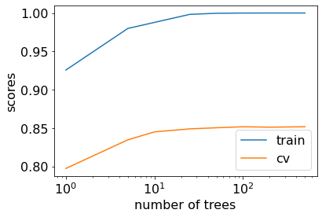

```python
make_num_tree_plot(
    preprocessor, X_train, y_train, X_test, y_test, [1, 5, 10, 25, 50, 100, 200, 500]
)
```

#### Number of trees and fundamental trade-off

- Above: seems like we're beating the fundamental "tradeoff" by increasing training score and not decreasing validation score much.
- This is the promise of ensembles, though it's not guaranteed to work so nicely.

More trees are always better! We pick less trees for speed.

### Strengths and weaknesses

- Usually one of the best performing off-the-shelf classifiers without heavy tuning of hyperparameters
- Don't require scaling of data
- Less likely to overfit
- Slower than decision trees because we are fitting multiple trees but can easily parallelize training because all trees are independent of each other (that said, sklearn implementation is kind of slow)
- In general, able to capture a much broader picture of the data compared to a single decision tree.

### Weaknesses

- Require more memory
- Hard to interpret
- Tend not to perform well on high dimensional sparse data such as text data

## ❓❓ Questions for you

**Select all of the following statements which are TRUE.**

- (A) Every tree in a random forest uses a different bootstrap sample of the training set.
- (B) To train a tree in a random forest, we first randomly select a subset of features. The tree is then restricted to only using those features.
- (C) A reasonable implementation of `predict_proba` for random forests would be for each tree to "vote" and then normalize these vote counts into probabilities.
- (D) Increasing the hyperparameter max_features (the number of features to consider for a split) makes the model more complex and moves the fundamental tradeoff toward lower training error.
- (E) A random forest with only one tree is likely to get a higher training error than a decision tree of the same depth.

## Gradient boosted trees

Another popular and effective class of tree-based models is gradient boosted trees.

- No randomization.
- The key idea is combining many simple models called weak learners to create a strong learner.
- They combine multiple shallow (depth 1 to 5) decision trees
- They build trees in a serial manner, where each tree tries to correct the mistakes of the previous one.

### Important hyperparameters

- `n_estimators`
  - control the number of trees to build
- `learning_rate`
  - controls how strongly each tree tries to correct the mistakes of the previous trees
  - higher learning rate means each tree can make stronger corrections, which means more complex model

We'll not go into the details. We'll look at brief examples of using the following three gradient boosted tree models.

- [XGBoost](https://xgboost.readthedocs.io/en/latest/)
- [LightGBM](https://lightgbm.readthedocs.io/en/latest/Python-Intro.html)
- [CatBoost](https://catboost.ai/docs/concepts/python-quickstart.html)

### [XGBoost](https://xgboost.ai/about)

- Not part of `sklearn` but has similar interface.
- Install it in your conda environment: `conda install -c conda-forge xgboost`
- Supports missing values
- GPU training, networked parallel training
- Supports sparse data
- Typically better scores than random forests

### [LightGBM](https://lightgbm.readthedocs.io/)

- Not part of `sklearn` but has similar interface.
- Install it in your conda environment: `conda install -c conda-forge lightgbm`
- Small model size
- Faster
- Typically better scores than random forests

### [CatBoost](https://catboost.ai/)

- Not part of `sklearn` but has similar interface.
- Install it in your conda environment: `conda install -c conda-forge catboost`
- Usually better scores but slower compared to `XGBoost` and `LightGBM`

```python
from catboost import CatBoostClassifier
from lightgbm.sklearn import LGBMClassifier
from sklearn.tree import DecisionTreeClassifier
from xgboost import XGBClassifier

pipe_lr = make_pipeline(
    preprocessor, LogisticRegression(max_iter=2000, random_state=123)
)
pipe_dt = make_pipeline(preprocessor, DecisionTreeClassifier(random_state=123))
pipe_rf = make_pipeline(preprocessor, RandomForestClassifier(random_state=123))
# pipe_xgb = make_pipeline(
#     preprocessor, XGBClassifier(random_state=123, eval_metric="logloss", verbosity=0)
# )
pipe_lgbm = make_pipeline(preprocessor, LGBMClassifier(random_state=123))
pipe_catboost = make_pipeline(
    preprocessor, CatBoostClassifier(verbose=0, random_state=123)
)
classifiers = {
    "logistic regression": pipe_lr,
    "decision tree": pipe_dt,
    "random forest": pipe_rf,
    #"XGBoost": pipe_xgb,
    "LightGBM": pipe_lgbm,
    "CatBoost": pipe_catboost,
}
```

```python
results = {}
```

```python
for (name, model) in classifiers.items():
    results[name] = mean_std_cross_val_scores(
        model, X_train, y_train, return_train_score=True, scoring=scoring_metric
    )
```

```python
pd.DataFrame(results).T
```

|  | fit_time | score_time | test_score | train_score |
| --- | --- | --- | --- | --- |
| Dummy | 0.004 (+/- 0.001) | 0.003 (+/- 0.000) | 0.636 (+/- 0.010) | 0.634 (+/- 0.005) |
| logistic regression | 0.348 (+/- 0.026) | 0.012 (+/- 0.001) | 0.849 (+/- 0.004) | 0.851 (+/- 0.001) |
| decision tree | 0.095 (+/- 0.003) | 0.013 (+/- 0.001) | 0.811 (+/- 0.002) | 1.000 (+/- 0.000) |
| random forest | 0.804 (+/- 0.005) | 0.053 (+/- 0.000) | 0.852 (+/- 0.004) | 1.000 (+/- 0.000) |
| LightGBM | 0.092 (+/- 0.001) | 0.014 (+/- 0.001) | 0.868 (+/- 0.003) | 0.907 (+/- 0.002) |
| CatBoost | 3.762 (+/- 0.043) | 0.055 (+/- 0.001) | 0.870 (+/- 0.001) | 0.906 (+/- 0.001) |

**Some observations**

- Keep in mind that all these results are with default hyperparameters
- Ideally we would carry out hyperparameter optimization for all of them and then compare the results.
- We are using a particular scoring metric (accuracy in this case)
- We are scaling numeric features but it shouldn't matter for these tree-based models.
- Look at the std. Doesn't look very high.
  - The scores look more or less stable.

```python
pd.DataFrame(results).T
```

|  | fit_time | score_time | test_score | train_score |
| --- | --- | --- | --- | --- |
| Dummy | 0.004 (+/- 0.001) | 0.003 (+/- 0.000) | 0.636 (+/- 0.010) | 0.634 (+/- 0.005) |
| logistic regression | 0.348 (+/- 0.026) | 0.012 (+/- 0.001) | 0.849 (+/- 0.004) | 0.851 (+/- 0.001) |
| decision tree | 0.095 (+/- 0.003) | 0.013 (+/- 0.001) | 0.811 (+/- 0.002) | 1.000 (+/- 0.000) |
| random forest | 0.804 (+/- 0.005) | 0.053 (+/- 0.000) | 0.852 (+/- 0.004) | 1.000 (+/- 0.000) |
| LightGBM | 0.092 (+/- 0.001) | 0.014 (+/- 0.001) | 0.868 (+/- 0.003) | 0.907 (+/- 0.002) |
| CatBoost | 3.762 (+/- 0.043) | 0.055 (+/- 0.001) | 0.870 (+/- 0.001) | 0.906 (+/- 0.001) |

### What classifier should I use?

**Simple answer**

- Whichever gets the highest CV score making sure that you're not overusing the validation set.

**Interpretability**

- This is an area of growing interest and concern in ML.
- How important is interpretability for you?
- Late we'll talk about interpretability of non-linear models.

**Speed/code maintenance**

- Other considerations could be speed (fit and/or predict), maintainability of the code.

Finally, you could use all of them!

## Averaging

Earlier we looked at a bunch of classifiers:

```python
classifiers.keys()
```

```
dict_keys(['logistic regression', 'decision tree', 'random forest', 'LightGBM', 'CatBoost'])
```

What if we use all these models and let them vote during prediction time?

```python
from sklearn.ensemble import VotingClassifier

averaging_model = VotingClassifier(
    list(classifiers.items()), voting="soft"
)  # need the list() here for cross_val to work!
```

```python
from sklearn import set_config

set_config(display="diagram")  # global setting
```

```python
averaging_model
```

```
VotingClassifier(estimators=[('logistic regression',
                              Pipeline(steps=[('columntransformer',
                                               ColumnTransformer(transformers=[('pipeline-1',
                                                                                Pipeline(steps=[('standardscaler',
                                                                                                 StandardScaler())]),
                                                                                ['age',
                                                                                 'fnlwgt',
                                                                                 'capital.gain',
                                                                                 'capital.loss',
                                                                                 'hours.per.week']),
                                                                               ('pipeline-2',
                                                                                Pipeline(steps=[('ordinalencoder',
                                                                                                 OrdinalEncoder(categories=[['Preschool',
                                                                                                                             '1st-4th'...
                                                                                                 SimpleImputer(fill_value='missing',
                                                                                                               strategy='constant')),
                                                                                                ('onehotencoder',
                                                                                                 OneHotEncoder(handle_unknown='ignore',
                                                                                                               sparse=False))]),
                                                                                ['workclass',
                                                                                 'marital.status',
                                                                                 'occupation',
                                                                                 'relationship',
                                                                                 'native.country']),
                                                                               ('drop',
                                                                                'drop',
                                                                                ['race',
                                                                                 'education.num'])])),
                                              ('catboostclassifier',
                                               <catboost.core.CatBoostClassifier object at 0x000002432AEF1248>)]))],
                 voting='soft')
```

This `VotingClassifier` will take a *vote* using the predictions of the constituent classifier pipelines.

Main parameter: `voting`

- `voting='hard'`
  - it uses the output of `predict` and actually votes.
- `voting='soft'`
  - with `voting='soft'` it averages the output of `predict_proba` and then thresholds / takes the larger.
- The choice depends on whether you trust `predict_proba` from your base classifiers - if so, it's nice to access that information.

```python
averaging_model.fit(X_train, y_train);
```

- What happens when you `fit` a `VotingClassifier`?
  - It will fit all constituent models.

```
{note}
It seems sklearn requires us to actually call `fit` on the `VotingClassifier`, instead of passing in pre-fit models. This is an implementation choice rather than a conceptual limitation.
```

Let's look at particular test examples where `income` is ">50k" (y=1):

```python
test_g50k = (
    test_df.query("income == '>50K'").sample(4, random_state=2).drop(columns=["income"])
)
test_l50k = (
    test_df.query("income == '<=50K'")
    .sample(4, random_state=2)
    .drop(columns=["income"])
)
```

```python
averaging_model.classes_
```

```
array(['<=50K', '>50K'], dtype=object)
```

```python
data = {"Voting classifier": averaging_model.predict(test_l50k)}
pd.DataFrame(data)
```

|  | Voting classifier |
| --- | --- |
| 0 | <=50K |
| 1 | >50K |
| 2 | <=50K |
| 3 | <=50K |

For hard voting, these are the votes:

```python
r1 = {
    name: classifier.predict(test_l50k)
    for name, classifier in averaging_model.named_estimators_.items()
}
data.update(r1)
pd.DataFrame(data)
```

|  | Voting classifier | logistic regression | decision tree | random forest | LightGBM | CatBoost |
| --- | --- | --- | --- | --- | --- | --- |
| 0 | <=50K | 0 | 0 | 0 | 0 | 0 |
| 1 | >50K | 1 | 1 | 1 | 1 | 0 |
| 2 | <=50K | 0 | 0 | 0 | 0 | 0 |
| 3 | <=50K | 0 | 0 | 0 | 0 | 0 |

For soft voting, these are the scores:

```python
r1 = {
    name: classifier.predict_proba(test_l50k)
    for name, classifier in averaging_model.named_estimators_.items()
}
r1
```

```
{'logistic regression': array([[0.99808015, 0.00191985],
        [0.46831018, 0.53168982],
        [0.97526536, 0.02473464],
        [0.95692804, 0.04307196]]),
 'decision tree': array([[1., 0.],
        [0., 1.],
        [1., 0.],
        [1., 0.]]),
 'random forest': array([[1.  , 0.  ],
        [0.33, 0.67],
        [0.99, 0.01],
        [0.81, 0.19]]),
 'LightGBM': array([[9.99463389e-01, 5.36610801e-04],
        [4.69000802e-01, 5.30999198e-01],
        [9.51290934e-01, 4.87090656e-02],
        [9.07706919e-01, 9.22930811e-02]]),
 'CatBoost': array([[0.99888791, 0.00111209],
        [0.55857933, 0.44142067],
        [0.96274841, 0.03725159],
        [0.90925194, 0.09074806]])}
```

(Aside: the probability scores from `DecisionTreeClassifier` are pretty bad)

Let's see how well this model performs.

```python
results["Voting"] = mean_std_cross_val_scores(averaging_model, X_train, y_train)
```

```python
pd.DataFrame(results).T
```

|  | fit_time | score_time | test_score | train_score |
| --- | --- | --- | --- | --- |
| Dummy | 0.004 (+/- 0.001) | 0.003 (+/- 0.000) | 0.636 (+/- 0.010) | 0.634 (+/- 0.005) |
| logistic regression | 0.348 (+/- 0.026) | 0.012 (+/- 0.001) | 0.849 (+/- 0.004) | 0.851 (+/- 0.001) |
| decision tree | 0.095 (+/- 0.003) | 0.013 (+/- 0.001) | 0.811 (+/- 0.002) | 1.000 (+/- 0.000) |
| random forest | 0.804 (+/- 0.005) | 0.053 (+/- 0.000) | 0.852 (+/- 0.004) | 1.000 (+/- 0.000) |
| LightGBM | 0.092 (+/- 0.001) | 0.014 (+/- 0.001) | 0.868 (+/- 0.003) | 0.907 (+/- 0.002) |
| CatBoost | 3.762 (+/- 0.043) | 0.055 (+/- 0.001) | 0.870 (+/- 0.001) | 0.906 (+/- 0.001) |
| Voting | 5.532 (+/- 0.087) | 0.146 (+/- 0.002) | 0.858 (+/- 0.004) | NaN |

It appears that here we didn't do much better than our best classifier :(.

Let's try removing decision tree classifier.

```python
classifiers_ndt = classifiers.copy()
del classifiers_ndt["decision tree"]
averaging_model_ndt = VotingClassifier(
    list(classifiers_ndt.items()), voting="soft"
)  # need the list() here for cross_val to work!

results["Voting_ndt"] = mean_std_cross_val_scores(
    averaging_model_ndt,
    X_train,
    y_train,
    return_train_score=True,
    scoring=scoring_metric,
)
```

```python
pd.DataFrame(results).T
```

|  | fit_time | score_time | test_score | train_score |
| --- | --- | --- | --- | --- |
| Dummy | 0.004 (+/- 0.001) | 0.003 (+/- 0.000) | 0.636 (+/- 0.010) | 0.634 (+/- 0.005) |
| logistic regression | 0.348 (+/- 0.026) | 0.012 (+/- 0.001) | 0.849 (+/- 0.004) | 0.851 (+/- 0.001) |
| decision tree | 0.095 (+/- 0.003) | 0.013 (+/- 0.001) | 0.811 (+/- 0.002) | 1.000 (+/- 0.000) |
| random forest | 0.804 (+/- 0.005) | 0.053 (+/- 0.000) | 0.852 (+/- 0.004) | 1.000 (+/- 0.000) |
| LightGBM | 0.092 (+/- 0.001) | 0.014 (+/- 0.001) | 0.868 (+/- 0.003) | 0.907 (+/- 0.002) |
| CatBoost | 3.762 (+/- 0.043) | 0.055 (+/- 0.001) | 0.870 (+/- 0.001) | 0.906 (+/- 0.001) |
| Voting | 5.532 (+/- 0.087) | 0.146 (+/- 0.002) | 0.858 (+/- 0.004) | NaN |
| Voting_ndt | 5.502 (+/- 0.075) | 0.138 (+/- 0.004) | 0.868 (+/- 0.005) | 0.929 (+/- 0.001) |

Still the results are not better than the best performing model.

- It didn't happen here but how could the average do better than the best model???
  - From the perspective of the best estimator (in this case CatBoost), why are you adding on worse estimators??

Here's how this can work:

| Example | log reg | rand forest | cat boost | Averaged model |
| --- | --- | --- | --- | --- |
| 1 | ✅ | ✅ | ❌ | ✅✅❌=>✅ |
| 2 | ✅ | ❌ | ✅ | ✅❌✅=>✅ |
| 3 | ❌ | ✅ | ✅ | ❌✅✅=>✅ |

In short, as long as the different models make different mistakes, this can work.

Why not always do this?

1. `fit`/`predict` time.
2. Reduction in interpretability.
3. Reduction in code maintainability (e.g. Netflix prize).

### What kind of estimators can we combine?

- You can combine
  - completely different estimators, or similar estimators.
  - estimators trained on different samples.
  - estimators with different hyperparameter values.

## Stacking

- Another type of ensemble is stacking.
- Instead of averaging the outputs of each estimator, instead use their outputs as *inputs to another model*.
- By default for classification, it uses logistic regression.
  - We don't need a complex model here necessarily, more of a weighted average.
  - The features going into the logistic regression are the classifier outputs, *not* the original features!
  - So the number of coefficients = the number of base estimators!

```python
from sklearn.ensemble import StackingClassifier
```

The code starts to get too slow here; so we'll remove CatBoost.

```python
classifiers_nocat = classifiers.copy()
del classifiers_nocat["CatBoost"]
```

```python
stacking_model = StackingClassifier(list(classifiers_nocat.items()))
```

```python
stacking_model.fit(X_train, y_train);
```

What's going on in here?

- It is doing cross-validation by itself by default (see [documentation](https://scikit-learn.org/stable/modules/generated/sklearn.ensemble.StackingClassifier.html))
  - It is fitting the base estimators on the training fold
  - And the predicting on the validation fold
  - And then fitting the meta-estimator on that output (on the validation fold)

> Note that estimators_ are fitted on the full X while final*estimator* is trained using cross-validated predictions of the base estimators using cross_val_predict.

Here is the input features (X) to the meta-model:

```python
valid_sample = train_df.sample(4, random_state=2).drop(columns=["income"])
```

```python
r3 = {
    name: pipe.predict_proba(valid_sample)
    for (name, pipe) in stacking_model.named_estimators_.items()
}
r3
```

```
{'logistic regression': array([[0.75537465, 0.24462535],
        [0.99487913, 0.00512087],
        [0.82484015, 0.17515985],
        [0.95884449, 0.04115551]]),
 'decision tree': array([[1., 0.],
        [1., 0.],
        [1., 0.],
        [1., 0.]]),
 'random forest': array([[0.89, 0.11],
        [1.  , 0.  ],
        [0.91, 0.09],
        [0.97, 0.03]]),
 'LightGBM': array([[6.39667886e-01, 3.60332114e-01],
        [9.99382317e-01, 6.17683085e-04],
        [8.15871800e-01, 1.84128200e-01],
        [9.83034210e-01, 1.69657901e-02]])}
```

- Our meta-model is logistic regression (which it is by default).
- Let's look at the learned coefficients.

```python
pd.DataFrame(
    data=stacking_model.final_estimator_.coef_[0],
    index=classifiers_nocat.keys(),
    columns=["Coefficient"],
)
```

|  | Coefficient |
| --- | --- |
| logistic regression | 1.668382 |
| decision tree | -0.069139 |
| random forest | 0.359191 |
| LightGBM | 4.577903 |

```python
stacking_model.final_estimator_.intercept_
```

```
array([-3.26552861])
```

- It seems that the LightGBM is being trusted the most.

```python
stacking_model.predict(test_g50k)
```

```
array(['<=50K', '>50K', '<=50K', '<=50K'], dtype=object)
```

```python
stacking_model.predict_proba(test_g50k)
```

```
array([[0.8092623 , 0.1907377 ],
       [0.37964999, 0.62035001],
       [0.77017423, 0.22982577],
       [0.60540812, 0.39459188]])
```

(This is the `predict_proba` from logistic regression)

Let's see how well this model performs.

```python
results["Stacking_nocat"] = mean_std_cross_val_scores(
    stacking_model, X_train, y_train, return_train_score=True, scoring=scoring_metric
)
```

```python
pd.DataFrame(results).T
```

|  | fit_time | score_time | test_score | train_score |
| --- | --- | --- | --- | --- |
| Dummy | 0.004 (+/- 0.001) | 0.003 (+/- 0.000) | 0.636 (+/- 0.010) | 0.634 (+/- 0.005) |
| logistic regression | 0.348 (+/- 0.026) | 0.012 (+/- 0.001) | 0.849 (+/- 0.004) | 0.851 (+/- 0.001) |
| decision tree | 0.095 (+/- 0.003) | 0.013 (+/- 0.001) | 0.811 (+/- 0.002) | 1.000 (+/- 0.000) |
| random forest | 0.804 (+/- 0.005) | 0.053 (+/- 0.000) | 0.852 (+/- 0.004) | 1.000 (+/- 0.000) |
| LightGBM | 0.092 (+/- 0.001) | 0.014 (+/- 0.001) | 0.868 (+/- 0.003) | 0.907 (+/- 0.002) |
| CatBoost | 3.762 (+/- 0.043) | 0.055 (+/- 0.001) | 0.870 (+/- 0.001) | 0.906 (+/- 0.001) |
| Voting | 5.532 (+/- 0.087) | 0.146 (+/- 0.002) | 0.858 (+/- 0.004) | NaN |
| Voting_ndt | 5.502 (+/- 0.075) | 0.138 (+/- 0.004) | 0.868 (+/- 0.005) | 0.929 (+/- 0.001) |
| Stacking_nocat | 7.235 (+/- 0.058) | 0.088 (+/- 0.001) | 0.870 (+/- 0.004) | 0.902 (+/- 0.004) |

- The situation here is a bit mind-boggling.
- On each fold of cross-validation it is doing cross-validation.
- This is really loops within loops within loops within loops...
- We can also try a different final estimator:
- Let's `DecisionTreeClassifier` as a final estimator.

```python
stacking_model_tree = StackingClassifier(
    list(classifiers_nocat.items()), final_estimator=DecisionTreeClassifier(max_depth=3)
)
```

The results are not very good. But we can look at the tree:

```python
stacking_model_tree.fit(X_train, y_train);
```

```python
display_tree(list(classifiers_nocat.keys()), stacking_model_tree.final_estimator_)
```

[figure not shown]

#### An effective strategy

- Randomly generate a bunch of models with different hyperparameter configurations, and then stack all the models.
- What is an advantage of ensembling multiple models as opposed to just choosing one of them?
  - You may get a better score.
- What is an disadvantage of ensembling multiple models as opposed to just choosing one of them?
  - Slower, more code maintenance issues.

## Summary

- You have a number of models in your toolbox now.
- Ensembles are usually pretty effective.
  - Tree-based classifiers are particularly popular and effective on a wide range of problems.
  - But they trade off code complexity and speed for prediction accuracy.
  - Don't forget that hyperparameter optimization multiplies the slowness of the code!
- Stacking is a bit slower than voting, but generally higher accuracy.
  - As a bonus, you get to see the coefficients for each base classifier.
- All the above models have equivalent regression models.

#### Relevant papers

- [Fernandez-Delgado et al. 2014](http://jmlr.org/papers/volume15/delgado14a/delgado14a.pdf) compared 179 classifiers on 121 datasets:
  - First best class of methods was Random Forest and second best class of methods was (RBF) SVMs.
- If you like to read original papers [here](https://www.stat.berkeley.edu/~breiman/randomforest2001.pdf) is the original paper on Random Forests by Leo Breiman.